# Feuille d’exercice

Thomas Vroylandt

24 mars 2020

# Contexte

On va s’intéresser aux données de la STMT sur les demandeurs d’emploi pour la Creuse en 2019. L’idée va être de sortir les principales statistiques sur ces personnes et d’analyser quelques grandes répartitions.

# Packages

- On créé un projet RStudio ;
- On charge les packages qui vont nous être utiles.

```r
library(tidyverse)
library(haven)
library(readxl)
```

# Import des données

- Sauvegarder les données en local dans un dossier `data` au sein du projet ;
- Importer les données dans un objet.

```r
df_stmt_creuse <- read_sas("data/stmt_2019_creuse.sas7bdat")
```

- Visualiser ces données :
  - Combien de lignes ?
  - Combien de colonnes ?
  - A quoi ressemblent les données ?

```r
dim(df_stmt_creuse)
```

```
## [1] 125759      8
```

```r
View(df_stmt_creuse)
```

- Les types de variables sont-ils cohérents avec leur contenu ?
- Sinon il faut recoder les variables (avec `as.character()` ou `as.numeric()`).

# Recodage des données

On va chercher ici à avoir des données propres :

## Renommer

- Renommer les variables en minuscule ;

```r
df_stmt_creuse_recode1 <- df_stmt_creuse %>%
  rename(
    moista = MOISTA,
    sex = SEX,
    typdem = TYPDEM,
    rome = ROME,
    catsta = CATSTA,
    trcancsta = TRCANCSTA,
    qlf = QLF,
    annnai = ANNNAI
  )
```

## Recodage des niveaux

- Pour le ROME, charger le référentiel et le joindre pour obtenir les libellés ;

```r
ref_rome <- read_xlsx("data/ref_rome.xlsx")
```

- Recoder le sexe en homme / femme ;
- Regrouper l’ancienneté en - 6 mois / 6 mois à 1 an / 1 an et plus ;
- Regrouper la qualification en employé / ouvrier / agent de maîtrise et technicien / cadre ;

```r
df_stmt_creuse_recode2 <- df_stmt_creuse_recode1 %>%
  left_join(ref_rome, by = c("rome" = "code_rome")) %>%
  mutate(
    sex = fct_recode(sex,
                     "Homme" = "1",
                     "Femme" = "2"),
    tr_anciennete = fct_collapse(
      trcancsta,
      "Moins de 6 mois" = c("10", "11"),
      "6 à 12 mois" = c("12"),
      "Un an et plus" = c("20", "30", "40")
    ),
    qualif = fct_collapse(
      qlf,
      "Ouvrier" = c("1", "2", "3", "4"),
      "Employé" = c("5", "6"),
      "AMT" = c("7", "8"),
      "Cadre" = "9"
    )
  )
```

## Calcul de variables

- Calculer l’âge ;
- Calculer l’année et le mois (avec la fonction `str_sub()`) ;

```r
df_stmt_creuse_recode3 <- df_stmt_creuse_recode2 %>%
  mutate(
    age = 2019 - annnai,
    annee = str_sub(moista, 1, 4),
    mois = str_sub(moista, 5, 7)
  )
```

## Sélection des variables

- Ne sélectionner que les variables d’intérêt.

```r
df_stmt_creuse_recode <- df_stmt_creuse_recode3 %>%
  select(annee, mois, typdem, catsta, rome, lib_rome, sex, tr_anciennete, qualif, age)
```

# Calcul des agrégats

On va ici chercher à calculer le nombre de demandeurs d’emploi entrants, sortants et en fin de mois sur l’année, pour les DE en catégorie A, B, C.

## DEE, DES et DEFM

- Filtrer sur les catégories A, B, C.

```r
df_stmt_creuse_abc <- df_stmt_creuse_recode %>%
  filter(catsta %in% c("A", "B", "C"))
```

Les règles de gestion sont les suivantes (en fonction de la variable typdem):

- les entrants : 3 et 4 ;
- les sortants : 2 et 5 ;
- la DEFM : 1 et 4.

Il faut donc :

- Coder trois compteurs en fonction de typdem ;
- Sommer ces compteurs par mois.

```r
df_stmt_agregat_creuse <- df_stmt_creuse_abc %>%
  mutate(nb_dee = if_else(typdem %in% c("3", "4"), 1, 0),
         nb_des = if_else(typdem %in% c("2", "5"), 1, 0),
         nb_defm = if_else(typdem %in% c("1", "4"), 1, 0)) %>%
  group_by(mois) %>%
  summarise(nb_dee = sum(nb_dee),
            nb_des = sum(nb_des),
            nb_defm = sum(nb_defm)) %>%
  ungroup()

df_stmt_agregat_creuse
```

```
## # A tibble: 12 x 4
##    mois  nb_dee nb_des nb_defm
##    <chr>  <dbl>  <dbl>   <dbl>
##  1 01       679    772    8636
##  2 02       552    699    8554
##  3 03       538    739    8420
##  4 04       580    732    8315
##  5 05       573    697    8277
##  6 06       542    718    8182
##  7 07       731    737    8286
##  8 08       620    669    8336
##  9 09       850    965    8364
## 10 10       639    903    8222
## 11 11       661    818    8167
## 12 12       561    665    8143
```

## Calcul de statistiques

On va faire une analyse rapide de ces données :

- Calculer la DEFM moyenne sur l’année ;
- Ainsi que l’écart-type.

```r
df_stmt_agregat_creuse %>%
  summarise(mean_defm = mean(nb_defm),
            sd_defm = sd(nb_defm))
```

```
## # A tibble: 1 x 2
##   mean_defm sd_defm
##       <dbl>   <dbl>
## 1     8325.    152.
```

## Par sexe

- Refaire le calcul des agrégats par sexe ;

```r
df_stmt_agregat_creuse_sex <- df_stmt_creuse_abc %>%
  mutate(nb_dee = if_else(typdem %in% c("3", "4"), 1, 0),
         nb_des = if_else(typdem %in% c("2", "5"), 1, 0),
         nb_defm = if_else(typdem %in% c("1", "4"), 1, 0)) %>%
  group_by(mois, sex) %>%
  summarise(nb_dee = sum(nb_dee),
            nb_des = sum(nb_des),
            nb_defm = sum(nb_defm)) %>%
  ungroup()

df_stmt_agregat_creuse_sex
```

```
## # A tibble: 24 x 5
##    mois  sex   nb_dee nb_des nb_defm
##    <chr> <fct>  <dbl>  <dbl>   <dbl>
##  1 01    Homme    355    398    4277
##  2 01    Femme    324    374    4359
##  3 02    Homme    288    392    4209
##  4 02    Femme    264    307    4345
##  5 03    Homme    287    383    4148
##  6 03    Femme    251    356    4272
##  7 04    Homme    314    401    4087
##  8 04    Femme    266    331    4228
##  9 05    Homme    329    360    4101
## 10 05    Femme    244    337    4176
## # ... with 14 more rows
```

- Calculer la part des femmes dans la DEFM de chaque mois.

```r
df_stmt_agregat_creuse_sex %>%
  group_by(mois) %>%
  mutate(part_femme = nb_defm / sum(nb_defm) * 100) %>%
  ungroup() %>%
  filter(sex == "Femme") %>%
  select(mois, part_femme)
```

```
## # A tibble: 12 x 2
##    mois  part_femme
##    <chr>      <dbl>
##  1 01          50.5
##  2 02          50.8
##  3 03          50.7
##  4 04          50.8
##  5 05          50.5
##  6 06          51.0
##  7 07          51.1
##  8 08          51.1
##  9 09          51.1
## 10 10          50.9
## 11 11          50.3
## 12 12          50.1
```

# Analyse de la DEFM de janvier

On va maintenant filtrer sur la DEFM de janvier et analyser les caractéristiques de la population.

## Tri à plat

- Filtrer sur la DEFM de janvier ;

```r
df_stmt_creuse_janv <- df_stmt_creuse_recode %>%
  filter(mois == "01" & typdem %in% c("1", "4"))
```

- Faire les tri à plat par tranche d’ancienneté, qualification et catégorie ;

```r
df_stmt_creuse_janv %>%
  group_by(tr_anciennete) %>%
  count() %>%
  ungroup() %>%
  mutate(part = round(n / sum(n) * 100, 1))
```

```
## # A tibble: 3 x 3
##   tr_anciennete       n  part
##   <fct>           <int> <dbl>
## 1 Moins de 6 mois  3643  37.1
## 2 6 à 12 mois      1655  16.9
## 3 Un an et plus    4520  46
```

```r
df_stmt_creuse_janv %>%
  group_by(qualif) %>%
  count() %>%
  ungroup() %>%
  mutate(part = round(n / sum(n) * 100, 1))
```

```
## # A tibble: 5 x 3
##   qualif      n  part
##   <fct>   <int> <dbl>
## 1 0         462   4.7
## 2 Ouvrier  2374  24.2
## 3 Employé  6016  61.3
## 4 AMT       610   6.2
## 5 Cadre     356   3.6
```

```r
df_stmt_creuse_janv %>%
  group_by(catsta) %>%
  count() %>%
  ungroup() %>%
  mutate(part = round(n / sum(n) * 100, 1))
```

```
## # A tibble: 5 x 3
##   catsta     n  part
##   <chr>  <int> <dbl>
## 1 A       5430  55.3
## 2 B       1224  12.5
## 3 C       1982  20.2
## 4 D        553   5.6
## 5 E        629   6.4
```

## Tri croisé

- Faire le croisement qualification / catégorie ;
- Calculer la part de chaque qualification au sein des catégories ;
- Mettre en forme le tableau.

```r
tri_croise <- df_stmt_creuse_janv %>%
  group_by(qualif, catsta) %>%
  count() %>%
  group_by(catsta) %>%
  mutate(part = round(n / sum(n) * 100, 1)) %>%
  ungroup()

tri_croise %>%
  select(-n) %>%
  pivot_wider(names_from = catsta, values_from = part)
```

```
## # A tibble: 5 x 6
##   qualif      A     B     C     D     E
##   <fct>   <dbl> <dbl> <dbl> <dbl> <dbl>
## 1 0         5.2   3.2   3.9   6.9   3.8
## 2 Ouvrier  26.4  16.7  20.6  22.6  32.4
## 3 Employé  58.4  69.4  67    61.8  51.7
## 4 AMT       6.1   6.9   5.5   5.1   8.7
## 5 Cadre     3.9   3.8   2.9   3.6   3.3
```

## Tops

- Quel sont les 10 métiers avec le plus de demandeurs d’emploi ?

```r
df_stmt_creuse_janv %>%
  filter(!is.na(lib_rome)) %>%
  group_by(rome, lib_rome) %>%
  count(sort = TRUE) %>%
  ungroup() %>%
  top_n(10, wt = n)
```

```
## # A tibble: 10 x 3
##    rome  lib_rome                                           n
##    <chr> <chr>                                          <int>
##  1 K1304 Services domestiques                             545
##  2 K1303 Assistance auprès d'enfants                      433
##  3 J1301 Personnel polyvalent des services hospitaliers   346
##  4 A1203 Entretien des espaces verts                      329
##  5 K2204 Nettoyage de locaux                              316
##  6 M1607 Secrétariat                                      245
##  7 D1507 Mise en rayon libre-service                      222
##  8 K1302 Assistance auprès d'adultes                      215
##  9 I1203 Maintenance des bâtiments et des locaux          200
## 10 M1602 Opérations administratives                       164
```

- Calculer l’âge moyen et médian par métier.

```r
df_rome_age <- df_stmt_creuse_janv %>%
  filter(!is.na(lib_rome)) %>%
  group_by(rome, lib_rome) %>%
  summarise(nb_defm = n(),
            age_mean = mean(age),
            age_median = median(age)) %>%
  ungroup()

df_rome_age
```

```
## # A tibble: 409 x 5
##    rome  lib_rome                                    nb_defm age_mean age_median
##    <chr> <chr>                                         <int>    <dbl>      <dbl>
##  1 A1101 Conduite d'engins agricoles et forestiers        11     35.3         39
##  2 A1201 Bûcheronnage et élagage                          37     43.9         43
##  3 A1202 Entretien des espaces naturels                   42     48.6         52
##  4 A1203 Entretien des espaces verts                     329     44.4         47
##  5 A1204 Protection du patrimoine naturel                 13     32.1         31
##  6 A1205 Sylviculture                                      7     31.1         29
##  7 A1301 Conseil et assistance technique en agricul~      11     38.5         31
##  8 A1302 Contrôle et diagnostic technique en agricu~       7     35.7         37
##  9 A1303 Ingénierie en agriculture et environnement~       9     34.6         32
## 10 A1401 Aide agricole de production fruitière ou v~      19     40.2         42
## # ... with 399 more rows
```

- Quels sont les 5 métiers les plus jeunes / plus âgés.

```r
df_rome_age %>%
  top_n(5, wt = age_mean)
```

```
## # A tibble: 8 x 5
##   rome  lib_rome                                     nb_defm age_mean age_median
##   <chr> <chr>                                          <int>    <dbl>      <dbl>
## 1 C1501 Gérance immobilière                                2     61         61
## 2 D1206 Réparation d'articles en cuir et matériaux ~       1     64         64
## 3 E1105 Coordination d'édition                             2     61         61
## 4 F1204 Sécurité et protection santé du BTP                1     61         61
## 5 H2204 Encadrement des industries de l'ameublement~       1     61         61
## 6 I1305 Installation et maintenance électronique           1     65         65
## 7 M1205 Direction administrative et financière             6     61.2       61.5
## 8 N2203 Exploitation des pistes aéroportuaires             1     63         63
```

```r
df_rome_age %>%
  top_n(5, wt = -age_mean)
```

```
## # A tibble: 5 x 5
##   rome  lib_rome                              nb_defm age_mean age_median
##   <chr> <chr>                                   <int>    <dbl>      <dbl>
## 1 G1302 Optimisation de produits touristiques       1     22         22
## 2 H2908 Modelage de matériaux non métalliques       2     24.5       24.5
## 3 J1402 Diététique                                  1     23         23
## 4 K1701 Personnel de la Défense                     1     21         21
## 5 K1706 Sécurité publique                           4     23.2       23
```

- Le refaire uniquement pour les métiers avec au moins 50 DE.

```r
df_rome_age %>%
  filter(nb_defm >= 50) %>%
  top_n(5, wt = age_mean)
```

```
## # A tibble: 5 x 5
##   rome  lib_rome                                  nb_defm age_mean age_median
##   <chr> <chr>                                       <int>    <dbl>      <dbl>
## 1 I1203 Maintenance des bâtiments et des locaux       200     47.6       51
## 2 K1304 Services domestiques                          545     48.2       52
## 3 K2204 Nettoyage de locaux                           316     45.9       48
## 4 M1601 Accueil et renseignements                     102     47.7       50.5
## 5 N4103 Conduite de transport en commun sur route      77     50.7       53
```

```r
df_rome_age %>%
  filter(nb_defm >= 50) %>%
  top_n(5, wt = -age_mean)
```

```
## # A tibble: 5 x 5
##   rome  lib_rome                                     nb_defm age_mean age_median
##   <chr> <chr>                                          <int>    <dbl>      <dbl>
## 1 A1407 Élevage bovin ou équin                            64     31.4       27
## 2 D1505 Personnel de caisse                              121     34.5       32
## 3 D1507 Mise en rayon libre-service                      222     33.6       29
## 4 G1204 Éducation en activités sportives                  54     32.9       29.5
## 5 I1604 Mécanique automobile et entretien de véhicu~      85     32.9       30
```

# Export des résultats

- Exporter le tri croisé qualification / catégorie.

```r
writexl::write_xlsx(tri_croise, "export_tri_croise.xlsx")
```

# BONUS : graphiques

- Faire le diagramme en barre de l’âge moyen par niveau de qualification ;

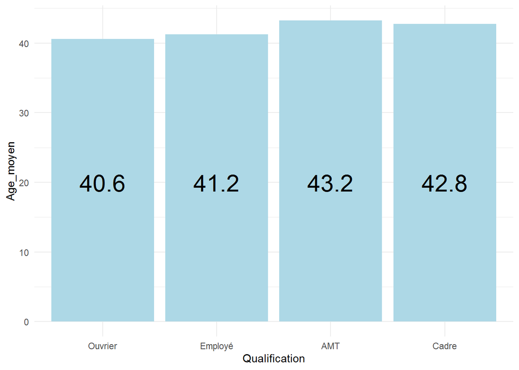

```r
df_stmt_creuse_janv %>%
  filter(qualif != "0") %>%
  group_by(qualif) %>%
  summarise(age_mean = mean(age)) %>%
  ggplot(aes(x = qualif, y = age_mean)) +
  geom_bar(stat = "identity", fill = "lightblue") +
  geom_text(aes(label = round(age_mean, 1)),
            size = 8,
            position = position_fill(vjust = 20)) +
  scale_x_discrete(name = "Qualification") +
  scale_y_continuous(name = "Age_moyen") +
  theme_minimal()
```

- Afficher l’âge moyen des femmes en fonction de la part des femmes par métier

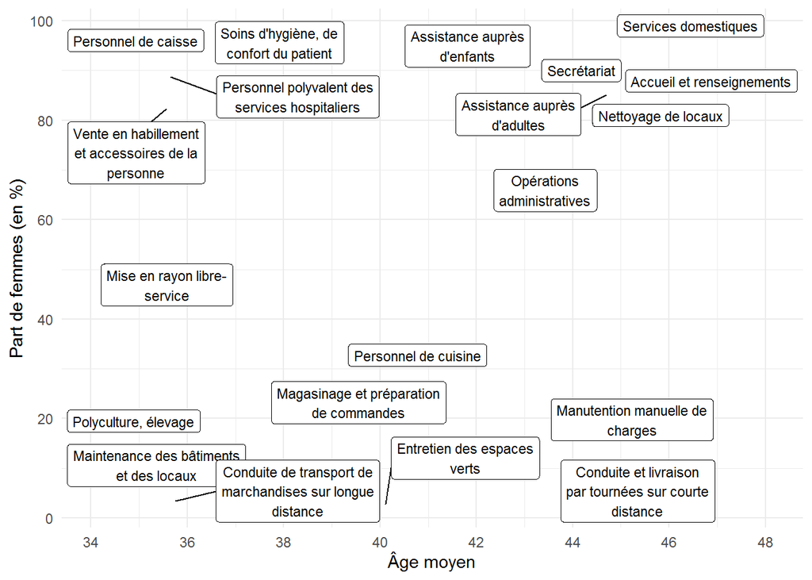

```r
df_stmt_creuse_janv %>%
  filter(!is.na(lib_rome)) %>%
  group_by(rome, lib_rome, sex) %>%
  summarise(age_mean = mean(age),
            n = n()) %>%
  group_by(rome, lib_rome) %>%
  mutate(part_femme = n / sum(n) * 100,
         n_tot = sum(n)) %>%
  filter(sex == "Femme") %>%
  ungroup() %>%
  top_n(20, wt = n_tot) %>%
  ggplot(aes(x = age_mean, y = part_femme, label = str_wrap(lib_rome, 25))) +
  ggrepel::geom_label_repel(size = 3) +
  scale_x_continuous(name = "Âge moyen", breaks = seq(20, 50, 2)) +
  scale_y_continuous(name = "Part de femmes (en %)", breaks = seq(0, 100, 20)) +
  theme_minimal()
```